# JPMorgan Chase and Co Quantitative Research - Job Simulation

This notebook is a collection of my solutions to the Forage JPMorgan Quant Research Job simulation tasks.

## JPMorgan Chase & Co. QR Job Sim - Task 1

We're provided here a csv file containing our price information, we use `pandas` to read this data into python;

```python
import pandas as pd
from datetime import datetime
from sklearn.linear_model import LinearRegression
from statsmodels.tsa.deterministic import CalendarFourier, DeterministicProcess
from sklearn.model_selection import train_test_split

data = pd.read_csv("sheets/Nat_Gas.csv")

display(data.head())
```

|  | Dates | Prices |
| --- | --- | --- |
| 0 | 10/31/20 | 10.1 |
| 1 | 11/30/20 | 10.3 |
| 2 | 12/31/20 | 11.0 |
| 3 | 1/31/21 | 10.9 |
| 4 | 2/28/21 | 10.9 |

Perfect! Now, we should be using dates as our index, and we ought to convert the dates into datetime format;

```python
data["Dates"] = data["Dates"].apply(lambda x : datetime.strptime(x, "%m/%d/%y"))

data = data.set_index(data["Dates"])

data = data.drop("Dates", axis=1)

data = data.resample("1D").asfreq()
data = data.interpolate(method = "linear")

display(data.head())
```

| Dates | Prices |
| --- | --- |
| 2020-10-31 | 10.100000 |
| 2020-11-01 | 10.106667 |
| 2020-11-02 | 10.113333 |
| 2020-11-03 | 10.120000 |
| 2020-11-04 | 10.126667 |

Now, we'll plot this on a graph to see what sort of features we might have;

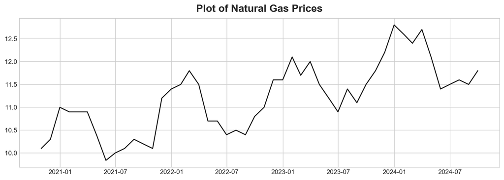

```python
import matplotlib.pyplot as plt
import seaborn as sns
plt.style.use("seaborn-v0_8-whitegrid")
plt.rc(
    "figure",
    autolayout=True,
    figsize=(11, 4),
    titlesize=18,
    titleweight='bold',
)
plt.rc(
    "axes",
    labelweight="bold",
    labelsize="large",
    titleweight="bold",
    titlesize=16,
    titlepad=10,
)
%config InlineBackend.figure_format = 'retina'

fig, ax = plt.subplots()
ax.plot(data, color='0.1')
ax.set_title('Plot of Natural Gas Prices');

plt.show()
```

There seems to be some seasonality here - we'll use `statsmodels` and its seasonal time series analysis to break it down

Now, we're going to use linear regression to fit a line to the trend, which looks almost linear, and use fourier curves to fit to the seasonal component;

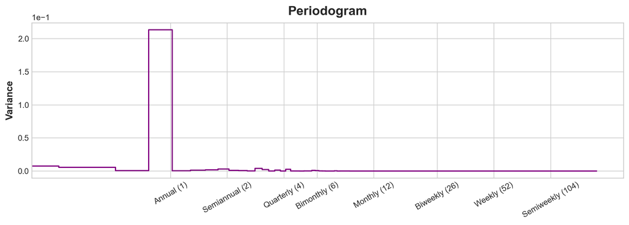

```python
def plot_periodogram(ts, detrend='linear', ax=None):
    from scipy.signal import periodogram
    fs = pd.Timedelta("365D") / pd.Timedelta("1D")
    freqencies, spectrum = periodogram(
        ts,
        fs=fs,
        detrend=detrend,
        window="boxcar",
        scaling='spectrum',
    )
    if ax is None:
        _, ax = plt.subplots()
    ax.step(freqencies, spectrum, color="purple")
    ax.set_xscale("log")
    ax.set_xticks([1, 2, 4, 6, 12, 26, 52, 104])
    ax.set_xticklabels(
        [
            "Annual (1)",
            "Semiannual (2)",
            "Quarterly (4)",
            "Bimonthly (6)",
            "Monthly (12)",
            "Biweekly (26)",
            "Weekly (52)",
            "Semiweekly (104)",
        ],
        rotation=30,
    )
    ax.ticklabel_format(axis="y", style="sci", scilimits=(0, 0))
    ax.set_ylabel("Variance")
    ax.set_title("Periodogram")
    return ax

plot_periodogram(data.Prices)
```

The Periodogram shows an annual seasonality, so, we apply the fourier as such:

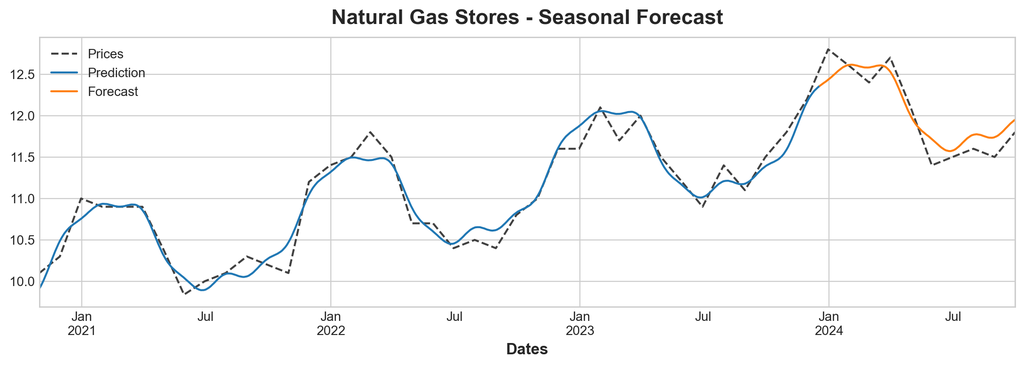

```python
fourier = CalendarFourier(freq="YE", order=6)  # I'm using order 6 to get enough complexity without overfitting to the data

data_train, data_test = train_test_split(data, shuffle = False, test_size = 0.2)

dp = DeterministicProcess(
    index=data_train.index,
    constant=True,               # dummy feature for bias (y-intercept)
    order=1,                     # trend (order 1 means linear)
    seasonal=True,
    additional_terms=[fourier],  # annual seasonality (fourier)
    drop=True,                   # drop terms to avoid collinearity
)

X_train = dp.in_sample()  # create features for dates in data.index
y_train = data_train["Prices"]

model = LinearRegression(fit_intercept=False)
_ = model.fit(X_train, y_train)

X_test = dp.out_of_sample(steps = len(data_test))

y_train_fit = pd.Series(model.predict(X_train), index=X_train.index)
y_test = pd.Series(model.predict(X_test), index=X_test.index)

ax = data.plot(color='0.25', style="--", title="Natural Gas Stores - Seasonal Forecast")
ax = y_train_fit.plot(ax=ax, label="Prediction")
ax = y_test.plot(ax=ax, label="Forecast")
_ = ax.legend()

plt.show();
```

We want to rate the accuracy of our test and training predictions:

```python
from sklearn.metrics import root_mean_squared_error
from sklearn.model_selection import cross_val_score

rmse_train = root_mean_squared_error(y_train_fit, y_train)
rmse_test = root_mean_squared_error(y_test, data_test["Prices"])

print(f"Root mean squared error of training set is {rmse_train}")
print(f"Root mean squared error of test set is {rmse_test}")
```

```
Root mean squared error of training set is 0.12388005217835862
Root mean squared error of test set is 0.16760476280464934
```

Now, I'm happy with its performace, so I'll train on the whole dataset and forecast one year.

```
RMSE is 0.12790688517432897
```

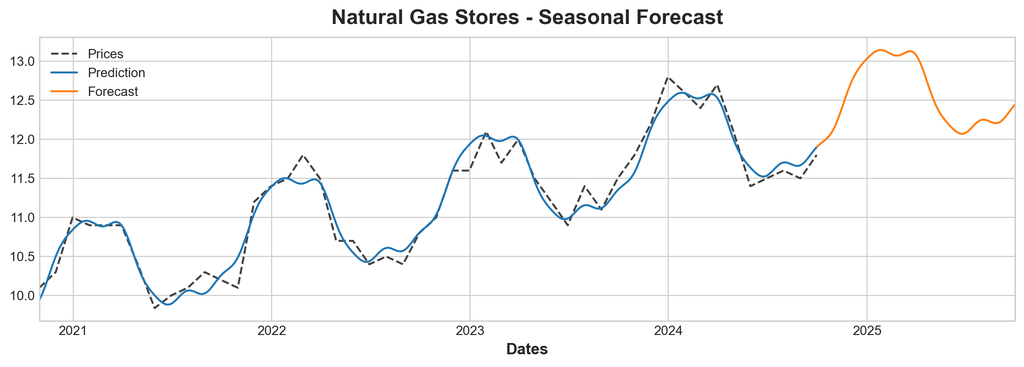

```python
fourier = CalendarFourier(freq="YE", order=6)  # I'm using order 6 to get enough complexity without overfitting to the data

dp = DeterministicProcess(
    index=data.index,
    constant=True,               # dummy feature for bias (y-intercept)
    order=1,                     # trend (order 1 means linear)
    seasonal=True,
    additional_terms=[fourier],  # annual seasonality (fourier)
    drop=True,                   # drop terms to avoid collinearity
)

X = dp.in_sample()  # create features for dates in data.index
y = data["Prices"]

model = LinearRegression(fit_intercept=False)
_ = model.fit(X, y)

X_fore = dp.out_of_sample(steps = 365)

y_fit = pd.Series(model.predict(X), index=X.index)
y_fore = pd.Series(model.predict(X_fore), index=X_fore.index)

ax = y.plot(color='0.25', style="--", title="Natural Gas Stores - Seasonal Forecast")
ax = y_fit.plot(ax=ax, label="Prediction")
ax = y_fore.plot(ax=ax, label="Forecast")
_ = ax.legend()

rmse = root_mean_squared_error(y_fit, data["Prices"])

print(f"RMSE is {rmse}")
plt.show();
```

```python
full_pred = pd.concat([y_fit, y_fore], join = "inner")
```

Now, we just need a way to pull specific date data

```python
userinput = str(input("Please input a date in the form mm/dd/yy :\n"))

userinput = datetime.strptime(userinput, "%m/%d/%y")

print(full_pred.loc[userinput])

# Input 10/12/23
```

```
11.422997191559919
```

So, we have increased the data granularity to daily, and forecast one year - as required!

## JPMorgan Chase & Co. QR Job Sim - Task 2

Let's load our data and model from the last task;

```python
"""
Natural Gas Price Forecasting
"""

### IMPORTS
import pandas as pd
from datetime import datetime
from sklearn.linear_model import LinearRegression
from statsmodels.tsa.deterministic import CalendarFourier, DeterministicProcess
import matplotlib.pyplot as plt

### DATA PRE-PROCESSING

# Reading data from csv stored in "sheets/Nat_Gas.csv"
data = pd.read_csv("sheets/Nat_Gas.csv")

# Applying datetime filter over "Dates" column
data["Dates"] = data["Dates"].apply(lambda x : datetime.strptime(x, "%m/%d/%y"))

# Converting index to Datetime format
data = data.set_index(data["Dates"])

# Removing Dates column
data = data.drop("Dates", axis=1)

# Increasing granularity by resampling data to daily and using linear interpolation to fill in gaps
data = data.resample("1D").asfreq()
data = data.interpolate(method = "linear")

### MODELLING

# Using order 6 to get enough complexity without overfitting to the data
fourier = CalendarFourier(freq="YE", order=6)

# Setting process
dp = DeterministicProcess(
    index=data.index,
    constant=True,
    order=1,
    seasonal=True,
    additional_terms=[fourier],
    drop=True
)

# Create features for dates in data.index and setting target y
X = dp.in_sample()
y = data["Prices"]

# Training lin-reg model to data
model = LinearRegression(fit_intercept=False)
_ = model.fit(X, y)

# Forecasting 365 steps (1 year)
X_fore = dp.out_of_sample(steps = 365)

# Fitting model
y_fit = pd.Series(model.predict(X), index=X.index)
y_fore = pd.Series(model.predict(X_fore), index=X_fore.index)

# Making final prediction dataset
full_pred = pd.concat([y_fit, y_fore], join = "inner")

### OUTPUTS

# Input management
#userinput = str(input("Please input a date in the form mm/dd/yy :\n"))

#userinput = datetime.strptime(userinput, "%m/%d/%y")

#print(full_pred.loc[userinput])
```

We want to make a function that takes inputs:

- Injection dates - we use $t$ to denote the date, $I$ to indicate the number of injections and $V_{I,t}$ to indicate injection volume in millions.
- Withdrawal dates - we use $t$ to denote the date, $W$ to indicate the number of withdrawals and $V_{W,t}$ to indicate withdrawal volume in millions.
- The prices at which the commodity can be purchased/sold on those dates $B_t$, $S_t$ (buy, sell) - based on our pricing model from task 1.
- The rate at which the gas can be injected/withdrawn $r_I$, $r_W$ million MMBtu per transaction.
- The cost of injecting and withdrawing $P_I$, $P_W$ per million MMBtu.
- The maximum volume that can be stored $V$.
- Storage costs $C$
- The duration of time in months between the first injection and final withdrawal $T$

And prices a contract according to some algorithm.

Let's go by the following equations to price our model: $$ P = \left(\sum (S_t - P_WV_{W,t}) - \sum (B_t - P_IV_{I,t})\right) - C T $$ $$ r_I \geq V_{I,t}\hspace{10mm} r_W \geq V_{W,t} $$ $$ V \geq \sum^t_\tau V_{I,\tau} - \sum^t_\tau V_{W,\tau} \hspace{10mm} \forall t $$

```python
from datetime import datetime, timedelta
import numpy as np
import math

# A function that takes parameters Injection/Withdrawal dates, amounts, rate and cost, Maximum Volume, Cost of storage, and prediction model results
def price_contract(InjectionDates, WithdrawalDates, InjectionAmount, WithdrawalAmount, InjectRate, WithdrawRate, InjectCost, WithdrawCost, MaxVol, StoreCost, prediction):
    # Set Contract Price variable
    ContractPrice = 0

    # Sort injection prices and amounts into a dataframe
    InjectionPrices = prediction[InjectionDates]
    WithdrawalPrices = prediction[WithdrawalDates]

    Injections = pd.concat([InjectionPrices, pd.Series(InjectionAmount, index = InjectionPrices.index)], axis = 1)
    Injections.columns = ["Injection Price", "Injection Amount"]

    Withdrawals = pd.concat([WithdrawalPrices, pd.Series(WithdrawalAmount, index = WithdrawalPrices.index)], axis = 1)
    Withdrawals.columns = ["Withdrawal Price", "Withdrawal Amount"]

    Operations = pd.concat([Injections, Withdrawals], axis = 1)

    # Set variables for how much gas is stored, and the change in value per transaction
    stored = 0
    value = []

    # This loop handles dealing with how much gas is in storage, how much we spend and earn, and handle potential errors
    for date in Operations.index:

        # Choosing the entry
        entry = Operations.loc[date]
        entry = entry.drop(entry[entry.isna()].index)

        # If the entry is an injection
        if entry.index.any() == "Injection Price":

            # If we're trying to inject more than allowed
            if entry["Injection Amount"] > InjectRate:
                return("Injection Error : Injection Amount greater than allowed rate")

            # If we have enough space to inject
            elif stored <= (MaxVol - entry["Injection Amount"]):
                stored += entry["Injection Amount"] # Add to storage
                value.append(-1 * (entry["Injection Price"] * entry["Injection Amount"] + InjectCost * (entry["Injection Amount"]/1000000))) # We spend : price*amount + cost*amount/mil

            # If we don't have enough space to inject
            else:
                return("Injection Error : Out of storage")

        # If the entry is a withdrawal
        else:
            # If we try to withdraw more than allowed
            if entry["Withdrawal Amount"] > WithdrawRate:
                return("Withdraw Error : Withdrawal Amount greater than allowed rate")

            # If we have enough gas to withdraw
            elif entry["Withdrawal Amount"] <= stored:
                stored -= entry["Withdrawal Amount"] # Remove from storage
                value.append(entry["Withdrawal Price"] * entry["Withdrawal Amount"] - WithdrawCost * (entry["Withdrawal Amount"]/1000000)) # We earn : price*amount - cost*amount/mil

            # If we try to withdraw more than we have
            else:
                return("Withdrawal Error : Out of storage")

    # Calculate the price of the contract
    timeelapsed = math.ceil((Operations.index[-1] - Operations.index[0]).days/30)
    ContractPrice = np.array(value).sum() - (StoreCost * timeelapsed)

    return(ContractPrice)

#Example input
Inj = [datetime(2024, 9, 30), datetime(2024, 10, 2), datetime(2024, 10, 12), datetime(2024, 10, 15)]
With = [datetime(2024, 12, 10), datetime(2024, 12, 30)]

InjAm = [5000000, 5000000, 5000000, 5000000]
WithAm = [15000000, 5000000]

price = price_contract(Inj, With, InjAm, WithAm, 5000000, 100000000, 10000, 10000, 50000000, 100000, full_pred)

print(price)
```

```
17968410.706561483
```

## JPMorgan Chase & Co. QR Job Sim - Task 3

For this task, we have a new dataset to work with, we'll load it with `pandas` as usual

```python
import pandas as pd

data = pd.read_csv("sheets\Loan_Data.csv", index_col="customer_id")

display(data.head())
```

| customer_id | credit_lines_outstanding | loan_amt_outstanding | total_debt_outstanding | income | years_employed | fico_score | default |
| --- | --- | --- | --- | --- | --- | --- | --- |
| 8153374 | 0 | 5221.545193 | 3915.471226 | 78039.38546 | 5 | 605 | 0 |
| 7442532 | 5 | 1958.928726 | 8228.752520 | 26648.43525 | 2 | 572 | 1 |
| 2256073 | 0 | 3363.009259 | 2027.830850 | 65866.71246 | 4 | 602 | 0 |
| 4885975 | 0 | 4766.648001 | 2501.730397 | 74356.88347 | 5 | 612 | 0 |
| 4700614 | 1 | 1345.827718 | 1768.826187 | 23448.32631 | 6 | 631 | 0 |

```python
data.isna().any()
```

```
credit_lines_outstanding    False
loan_amt_outstanding        False
total_debt_outstanding      False
income                      False
years_employed              False
fico_score                  False
default                     False
dtype: bool
```

Luckily the data looks well cleaned, so, all we have to do is fit some sort of model to this. I'll use a random forest classifier here with `default` as the target.

By intuition, I also think all of the columns might be relevant to whether the customer defaults - but I'll replace payment, debt and income with payment/income and debt/income.

```python
from sklearn.ensemble import RandomForestClassifier
from sklearn.model_selection import train_test_split
from sklearn.metrics import mean_absolute_error

data["loan_to_income"] = data['loan_amt_outstanding'] / data['income']
data['debt_to_income'] = data['total_debt_outstanding'] / data['income']

features = ['credit_lines_outstanding', 'debt_to_income', 'loan_to_income', 'years_employed', 'fico_score']

X = data.drop("default", axis = 1)[features]
y = data["default"]

X_train, X_test, y_train, y_test = train_test_split(X, y)

model = RandomForestClassifier()

model.fit(X_train, y_train)

y_pred = pd.Series(model.predict(X_test), index = X_test.index)
```

I now want to test this model's performance on the testing set

```
Model AUC Score : 0.9953184938421159
```

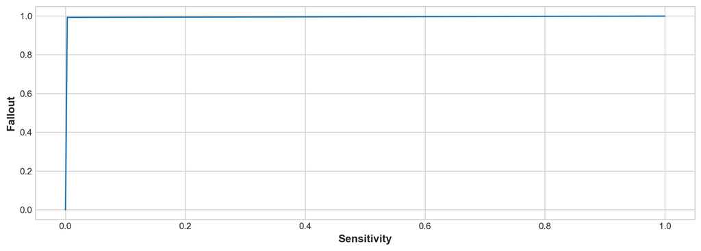

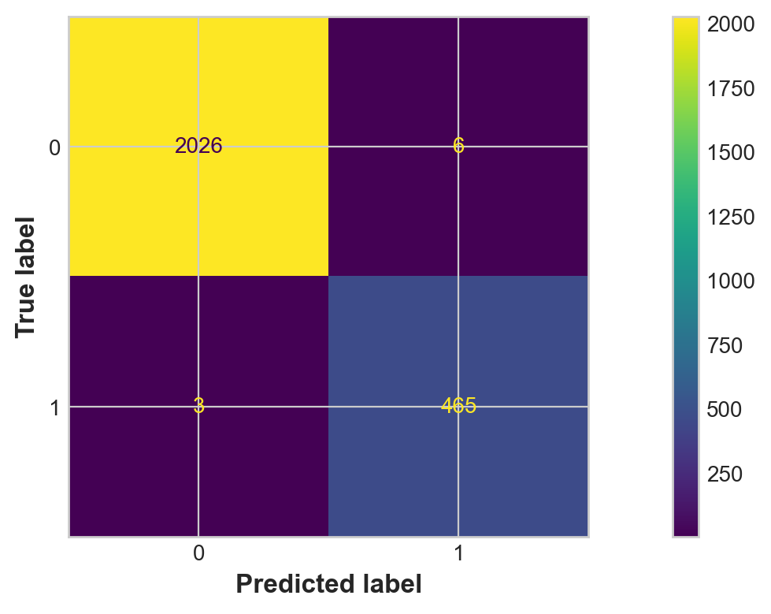

```python
from sklearn.metrics import ConfusionMatrixDisplay, confusion_matrix, roc_auc_score, roc_curve
import matplotlib.pyplot as plt

cfmatrix = confusion_matrix(y_test, y_pred)

# AUC Implementation

def plot_roc_curve(truey, yprob):
    falsep, truep, t = roc_curve(truey, yprob)
    plt.plot(falsep, truep)
    plt.xlabel("Sensitivity")
    plt.ylabel("Fallout")

print(f"Model AUC Score : {roc_auc_score(y_test, y_pred)}")
plot_roc_curve(y_test, y_pred)

cm_display = ConfusionMatrixDisplay(confusion_matrix=cfmatrix, display_labels=[0,1])

cm_display.plot()
plt.show()
```

Perfect - it seems we have a pretty strong model, now, we need to make a function to take features as input and return the expected loss on the loan.

```python
# Function takes all important features as input
def exploss(creditlines, loanamt, debtamt, income, employedyears, fico, model):

    # Creates customer profile
    information = [creditlines, debtamt/income, loanamt/income, employedyears, fico]
    customer = pd.DataFrame(information)
    customer = customer.transpose()
    customer.columns = ['credit_lines_outstanding', 'debt_to_income', 'loan_to_income', 'years_employed', 'fico_score']

    # Get probability of defaulting
    probdefault = (model.predict_proba(customer)[0][1])

    # We use recov rate 0.1
    recov = 0.1
    LGD = (1-0.1) * loanamt
    ExpectedLoss = LGD * probdefault
    return(ExpectedLoss)


exploss(3, 195248, 82282939, 26648, 6, 57, model)
```

```
101919.456
```

## JPMorgan Chase & Co. QR Job Sim - Task 4

Let's load our dataset:

```python
import pandas as pd
import numpy as np

data = pd.read_csv("sheets\Loan_Data.csv", index_col="customer_id")

display(data.head())
```

| customer_id | credit_lines_outstanding | loan_amt_outstanding | total_debt_outstanding | income | years_employed | fico_score | default |
| --- | --- | --- | --- | --- | --- | --- | --- |
| 8153374 | 0 | 5221.545193 | 3915.471226 | 78039.38546 | 5 | 605 | 0 |
| 7442532 | 5 | 1958.928726 | 8228.752520 | 26648.43525 | 2 | 572 | 1 |
| 2256073 | 0 | 3363.009259 | 2027.830850 | 65866.71246 | 4 | 602 | 0 |
| 4885975 | 0 | 4766.648001 | 2501.730397 | 74356.88347 | 5 | 612 | 0 |
| 4700614 | 1 | 1345.827718 | 1768.826187 | 23448.32631 | 6 | 631 | 0 |

We will always try to maximise the log-likelihood function as our indication of well optimised.

```python
from optbinning import OptimalBinning

def loglike(n, k, b):
    n = np.array(n)
    k = np.array(k)
    b = np.array(b)

    p = k/n

    loglikelihood = (k * np.log(p) + (n - k) * np.log(1-p)).sum()

    return(loglikelihood)


variable = "fico_score"
x = data[variable].values
y = data.default

optb = OptimalBinning(name=variable, dtype="numerical")

optb.fit(x, y)

bins = optb.splits
bins = np.append(bins, np.array([850]))
bins = np.append(np.array([0]), bins)

labels = np.arange(len(bins)-1, 0, -1)

data["rating"] = pd.cut(data["fico_score"], bins = bins, labels = labels)

data.sort_values("fico_score")
```

| customer_id | credit_lines_outstanding | loan_amt_outstanding | total_debt_outstanding | income | years_employed | fico_score | default | rating |
| --- | --- | --- | --- | --- | --- | --- | --- | --- |
| 7264776 | 1 | 4457.914800 | 12233.495010 | 98913.32028 | 3 | 408 | 0 | 11 |
| 6901345 | 3 | 5281.352243 | 16411.518010 | 79905.09892 | 1 | 409 | 1 | 11 |
| 2585781 | 4 | 6734.984475 | 26384.584390 | 97668.03091 | 2 | 418 | 1 | 11 |
| 1252008 | 5 | 5176.915602 | 22990.265430 | 82417.59227 | 2 | 425 | 1 | 11 |
| 1337395 | 5 | 4271.314690 | 22756.281030 | 83475.30929 | 4 | 438 | 1 | 11 |
| ... | ... | ... | ... | ... | ... | ... | ... | ... |
| 2967189 | 2 | 4803.995367 | 12920.809080 | 82500.95110 | 8 | 828 | 0 | 1 |
| 2214311 | 1 | 3590.741275 | 8071.647089 | 71796.25458 | 8 | 831 | 0 | 1 |
| 2713140 | 0 | 3566.709054 | 4400.583413 | 60204.65020 | 4 | 831 | 0 | 1 |
| 5062008 | 0 | 780.213472 | 273.300211 | 10258.24788 | 3 | 835 | 0 | 1 |
| 1096584 | 0 | 4107.822428 | 2009.745931 | 68276.98078 | 5 | 850 | 0 | 1 |

10000 rows × 8 columns

```python
from sklearn.ensemble import RandomForestClassifier
from sklearn.model_selection import train_test_split
from sklearn.metrics import mean_absolute_error

features = ['rating']

X = data.drop("default", axis = 1)[features]
y = data["default"]

X_train, X_test, y_train, y_test = train_test_split(X, y)

model = RandomForestClassifier()

model.fit(X_train, y_train)

y_pred = pd.Series(model.predict(X_test), index = X_test.index)
```

```
Model AUC Score : 0.5847893376992147
```

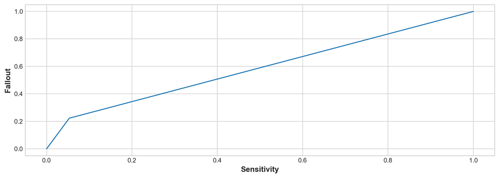

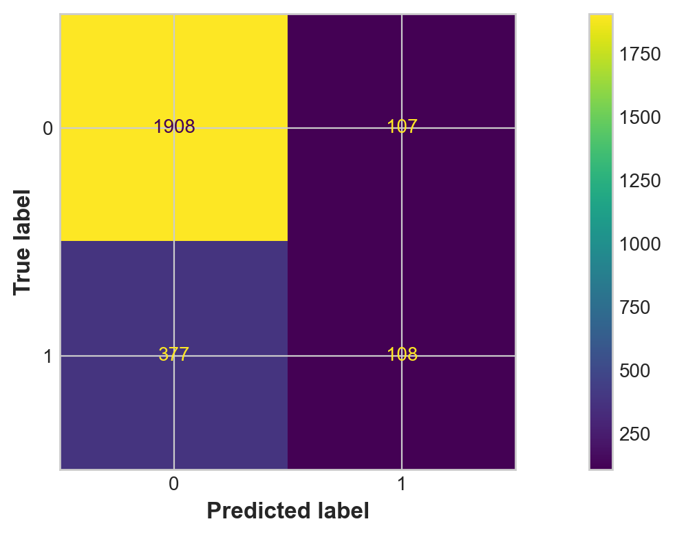

```python
from sklearn.metrics import ConfusionMatrixDisplay, confusion_matrix, roc_auc_score, roc_curve
import matplotlib.pyplot as plt

cfmatrix = confusion_matrix(y_test, y_pred)

# AUC Implementation

def plot_roc_curve(truey, yprob):
    falsep, truep, t = roc_curve(truey, yprob)
    plt.plot(falsep, truep)
    plt.xlabel("Sensitivity")
    plt.ylabel("Fallout")

print(f"Model AUC Score : {roc_auc_score(y_test, y_pred)}")
plot_roc_curve(y_test, y_pred)

cm_display = ConfusionMatrixDisplay(confusion_matrix=cfmatrix, display_labels=[0,1])

cm_display.plot()
plt.show()
```

The model does not perform very well expectedly, as just fico scores aren't really enough to make a good evaluation of a customer